# Comparative sequence analysis of the influenza A hemagglutinin (HA) gene

ICA3 Bioinformatics 2026

Bavaruba Kuventhirarasa

2026-11-14

# 1. Aim

Compare 12 HA gene sequences of influenza A (H1N1) viruses collected in Sri Lanka in 2009-2011 (NCBI GenBank) to:

1. describe nucleotide composition and GC content,
2. align the sequences and identify conserved and variable regions,
3. explore the genetic relationships among the viruses with phylogenetic trees.

**Before knitting:** run `code/01_prepare_data.R` once (from the project root) so that `data/ha_sequences.fasta` and `data/ha_metadata.csv` exist.

# 2. Packages

```r
library(tidyverse)
library(Biostrings)   # sequence objects, composition
library(msa)          # multiple sequence alignment (Clustal Omega)
library(ape)          # distances, trees, bootstrap
library(pheatmap)     # identity heatmap
library(RColorBrewer)
```

# 3. Data import and cleaning

```r
meta <- read_csv("../data/ha_metadata.csv", show_col_types = FALSE)
fa   <- readDNAStringSet("../data/ha_sequences.fasta")

# FASTA headers start with the accession.version; use it to attach our labels
names(fa) <- sub(" .*", "", names(fa))
stopifnot(all(meta$accession %in% names(fa)))
fa <- fa[meta$accession]
names(fa) <- meta$label        # label = accession_location_year

# Force upper case and look at the data
meta <- meta |> mutate(length = width(fa))
table(meta$subtype)
```

```
##
## H1N1
##   12
```

```r
meta |> select(label, subtype, location, year, length)
```

| label | subtype | location | year | length |
| --- | --- | --- | --- | --- |
| KC190041_Sri_Lanka_2009 | H1N1 | Sri Lanka | 2009 | 1701 |
| KC190042_Sri_Lanka_2009 | H1N1 | Sri Lanka | 2009 | 1701 |
| KC190043_Sri_Lanka_2009 | H1N1 | Sri Lanka | 2009 | 1701 |
| KC190044_Sri_Lanka_2009 | H1N1 | Sri Lanka | 2009 | 1701 |
| KC190045_Sri_Lanka_2010 | H1N1 | Sri Lanka | 2010 | 1701 |
| KC190046_Sri_Lanka_2010 | H1N1 | Sri Lanka | 2010 | 1701 |
| KC190047_Sri_Lanka_2010 | H1N1 | Sri Lanka | 2010 | 1701 |
| KC190048_Colombo_2010 | H1N1 | Colombo | 2010 | 1701 |
| KC190049_Colombo_2010 | H1N1 | Colombo | 2010 | 1701 |
| KC190050_Karapitiya_2011 | H1N1 | Karapitiya | 2011 | 1701 |

[output cut: 2 more lines]

## 3.1 Sequence quality checks

Ambiguous bases (N, R, Y, …) reduce alignment quality, so we count them.

```r
freq <- alphabetFrequency(fa, baseOnly = TRUE)   # columns A C G T other

qc <- tibble(
  label     = names(fa),
  subtype   = meta$subtype,
  year      = meta$year,
  length    = width(fa),
  ambiguous = freq[, "other"]
)
qc
```

| label | subtype | year | length | ambiguous |
| --- | --- | --- | --- | --- |
| KC190041_Sri_Lanka_2009 | H1N1 | 2009 | 1701 | 0 |
| KC190042_Sri_Lanka_2009 | H1N1 | 2009 | 1701 | 0 |
| KC190043_Sri_Lanka_2009 | H1N1 | 2009 | 1701 | 0 |
| KC190044_Sri_Lanka_2009 | H1N1 | 2009 | 1701 | 0 |
| KC190045_Sri_Lanka_2010 | H1N1 | 2010 | 1701 | 0 |
| KC190046_Sri_Lanka_2010 | H1N1 | 2010 | 1701 | 0 |
| KC190047_Sri_Lanka_2010 | H1N1 | 2010 | 1701 | 0 |
| KC190048_Colombo_2010 | H1N1 | 2010 | 1701 | 0 |
| KC190049_Colombo_2010 | H1N1 | 2010 | 1701 | 1 |
| KC190050_Karapitiya_2011 | H1N1 | 2011 | 1701 | 1 |

[output cut: 2 more lines]

```r
# Remove sequences with more than 1% ambiguous bases (none expected)
bad <- qc$label[qc$ambiguous / qc$length > 0.01]
if (length(bad) > 0) {
  fa   <- fa[!names(fa) %in% bad]
  meta <- meta[!meta$label %in% bad, ]
  message("Removed ", length(bad), " sequence(s) with >1% ambiguous bases")
}
```

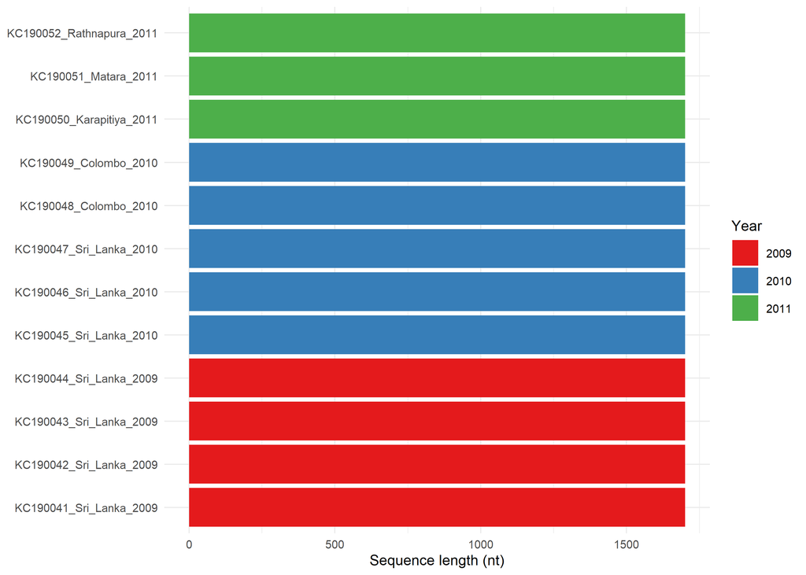

Figure 1. Length of each HA sequence (nucleotides), coloured by year of collection.

```r
ggplot(qc, aes(x = reorder(label, length), y = length, fill = factor(year))) +
  geom_col() +
  coord_flip() +
  scale_fill_brewer(palette = "Set1") +
  labs(x = NULL, y = "Sequence length (nt)", fill = "Year") +
  theme_minimal(base_size = 9)
```

# 4. Nucleotide composition and GC content

```r
freq <- alphabetFrequency(fa, baseOnly = TRUE)
acgt <- rowSums(freq[, c("A", "C", "G", "T")])

comp <- tibble(
  label   = names(fa),
  subtype = meta$subtype,
  year    = meta$year,
  A  = 100 * freq[, "A"] / acgt,
  T  = 100 * freq[, "T"] / acgt,
  G  = 100 * freq[, "G"] / acgt,
  C  = 100 * freq[, "C"] / acgt
) |>
  mutate(GC = G + C)

write_csv(comp, "../results/nucleotide_composition.csv")
comp |> mutate(across(where(is.numeric), ~ round(.x, 2)))
```

| label | subtype | year | A | T | G | C | GC |
| --- | --- | --- | --- | --- | --- | --- | --- |
| KC190041_Sri_Lanka_2009 | H1N1 | 2009 | 35.27 | 24.04 | 22.28 | 18.40 | 40.68 |
| KC190042_Sri_Lanka_2009 | H1N1 | 2009 | 35.45 | 23.99 | 22.10 | 18.46 | 40.56 |
| KC190043_Sri_Lanka_2009 | H1N1 | 2009 | 35.27 | 23.93 | 22.28 | 18.52 | 40.80 |
| KC190044_Sri_Lanka_2009 | H1N1 | 2009 | 35.21 | 23.93 | 22.34 | 18.52 | 40.86 |
| KC190045_Sri_Lanka_2010 | H1N1 | 2010 | 35.51 | 23.93 | 21.99 | 18.58 | 40.56 |
| KC190046_Sri_Lanka_2010 | H1N1 | 2010 | 35.51 | 23.93 | 21.99 | 18.58 | 40.56 |
| KC190047_Sri_Lanka_2010 | H1N1 | 2010 | 35.51 | 23.99 | 21.99 | 18.52 | 40.51 |
| KC190048_Colombo_2010 | H1N1 | 2010 | 35.57 | 23.87 | 21.93 | 18.64 | 40.56 |
| KC190049_Colombo_2010 | H1N1 | 2010 | 35.53 | 23.94 | 21.94 | 18.59 | 40.53 |
| KC190050_Karapitiya_2011 | H1N1 | 2011 | 35.53 | 23.94 | 21.94 | 18.59 | 40.53 |

[output cut: 2 more lines]

```r
comp |>
  group_by(year) |>
  summarise(n = n(), mean_A = mean(A), mean_T = mean(T),
            mean_G = mean(G), mean_C = mean(C),
            mean_GC = mean(GC), sd_GC = sd(GC), .groups = "drop") |>
  mutate(across(where(is.numeric), ~ round(.x, 2)))
```

| year | n | mean_A | mean_T | mean_G | mean_C | mean_GC | sd_GC |
| --- | --- | --- | --- | --- | --- | --- | --- |
| 2009 | 4 | 35.30 | 23.97 | 22.25 | 18.47 | 40.73 | 0.13 |
| 2010 | 5 | 35.52 | 23.93 | 21.97 | 18.58 | 40.55 | 0.03 |
| 2011 | 3 | 35.50 | 23.91 | 21.95 | 18.63 | 40.58 | 0.11 |

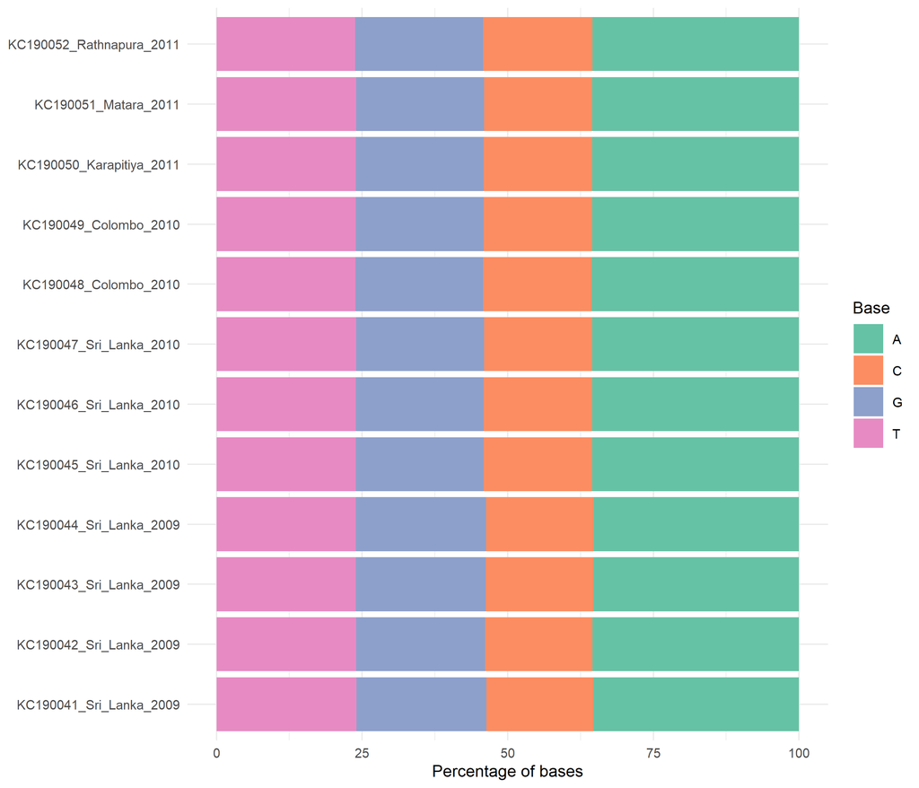

Figure 2. Nucleotide composition (% A, C, G, T) of each HA sequence.

```r
comp |>
  pivot_longer(c(A, C, G, T), names_to = "base", values_to = "percent") |>
  ggplot(aes(x = label, y = percent, fill = base)) +
  geom_col() +
  coord_flip() +
  scale_fill_brewer(palette = "Set2") +
  labs(x = NULL, y = "Percentage of bases", fill = "Base") +
  theme_minimal(base_size = 9)
```

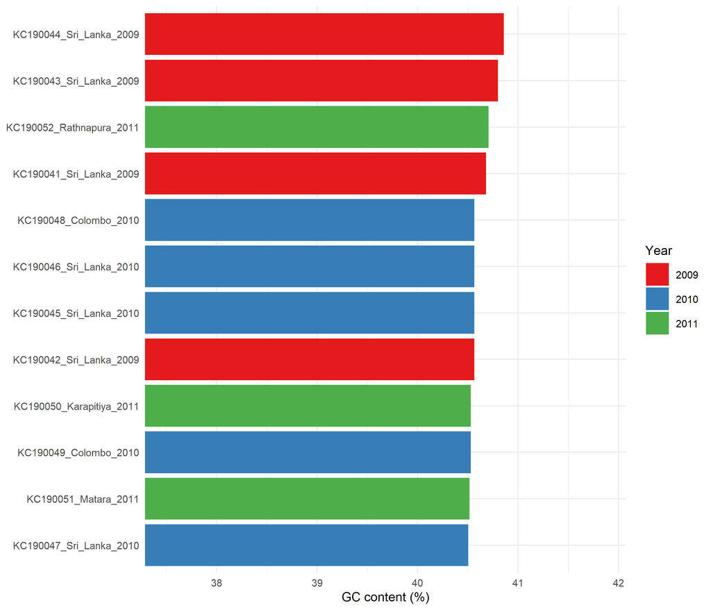

Figure 3. GC content (%) of each HA sequence, coloured by year of collection.

```r
ggplot(comp, aes(x = reorder(label, GC), y = GC, fill = factor(year))) +
  geom_col() +
  coord_flip(ylim = c(min(comp$GC) - 3, max(comp$GC) + 1)) +
  scale_fill_brewer(palette = "Set1") +
  labs(x = NULL, y = "GC content (%)", fill = "Year") +
  theme_minimal(base_size = 9)
```

Does GC content differ between years of collection (2009, 2010, 2011)? With small groups we use a non-parametric Kruskal-Wallis test.

```r
if (n_distinct(comp$year) > 1) {
  gc_test <- kruskal.test(GC ~ factor(year), data = comp)
  print(gc_test)
} else {
  message("Only one year in the data, so the test is skipped.")
}
```

```
##
##  Kruskal-Wallis rank sum test
##
## data:  GC by factor(year)
## Kruskal-Wallis chi-squared = 4.7077, df = 2, p-value = 0.095
```

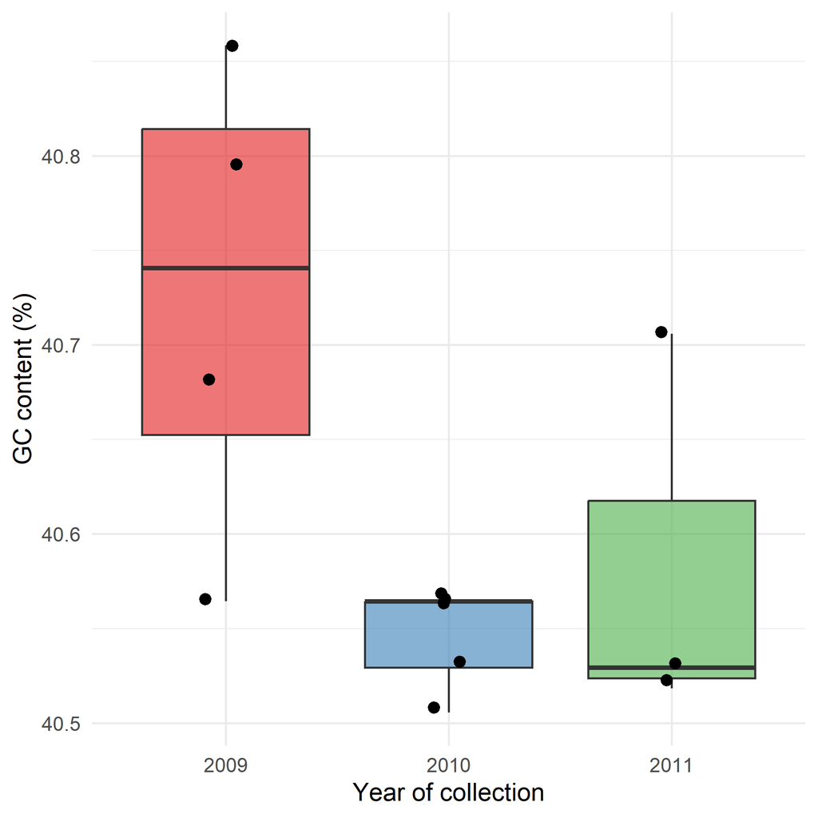

Figure 4. GC content by year of collection (points = individual sequences).

```r
ggplot(comp, aes(x = factor(year), y = GC, fill = factor(year))) +
  geom_boxplot(alpha = 0.6, outlier.shape = NA) +
  geom_jitter(width = 0.1, size = 2) +
  scale_fill_brewer(palette = "Set1") +
  labs(x = "Year of collection", y = "GC content (%)") +
  theme_minimal() + theme(legend.position = "none")
```

# 5. Helper functions for alignment, conservation and trees

These functions are used for the conservation, identity and tree analysis of the H1N1 alignment.

```r
# ---- 1. multiple sequence alignment (Clustal Omega) ------------------------
run_alignment <- function(st) {
  ids <- meta$label[meta$subtype == st]
  aln <- msa(fa[ids], method = "ClustalOmega", type = "dna",
             order = "input", verbose = FALSE)
  m <- as.matrix(as(aln, "DNAStringSet"))        # sequences x positions
  list(aln = aln, m = m, dnabin = as.DNAbin(m), ids = ids)
}

# ---- 2. per-position statistics -------------------------------------------
site_stats <- function(m, window = 30) {
  bases <- c("A", "C", "G", "T")
  stats <- map_dfr(seq_len(ncol(m)), function(j) {
    col <- m[, j]
    x   <- col[col %in% bases]
    tibble(
      pos      = j,
      gap_frac = mean(col == "-"),
      top_frac = if (length(x)) max(table(x)) / length(x) else NA_real_,
      entropy  = if (length(x)) { p <- table(x) / length(x); -sum(p * log2(p)) } else NA_real_
    )
  })
  stats |>
    mutate(
      variable = !is.na(top_frac) & top_frac < 1,     # >= 2 different bases
      win_cons = as.numeric(stats::filter(top_frac, rep(1 / window, window), sides = 2))
    )
}

# ---- 3. blocks of >= min_len consecutive identical, gap-free positions -----
conserved_blocks <- function(ss, min_len = 30) {
  r <- rle(!ss$variable & ss$gap_frac == 0)
  ends   <- cumsum(r$lengths)
  starts <- ends - r$lengths + 1
  tibble(start = starts, end = ends, length = r$lengths, conserved = r$values) |>
    filter(conserved, length >= min_len) |>
    select(start, end, length)
}

# ---- 4. plots ---------------------------------------------------------------
plot_conservation <- function(ss, st) {
  ggplot(ss, aes(pos, win_cons)) +
    geom_line(colour = "steelblue", linewidth = 0.6) +
    labs(x = "Alignment position (nt)",
         y = "Conservation (30-nt window)",
         title = paste(st, "- conservation along the HA alignment")) +
    coord_cartesian(ylim = c(min(ss$win_cons, na.rm = TRUE) - 0.01, 1)) +
    theme_minimal()
}

plot_variable_bins <- function(ss, st, bin = 100) {
  ss |>
    mutate(bin = (pos - 1) %/% bin * bin + 1) |>
    group_by(bin) |>
    summarise(variable_sites = sum(variable), .groups = "drop") |>
    ggplot(aes(bin, variable_sites)) +
    geom_col(fill = "firebrick", width = bin * 0.9) +
    labs(x = "Alignment position (start of 100-nt bin)",
         y = "Variable sites per 100 nt",
         title = paste(st, "- variable sites")) +
    theme_minimal()
}

plot_identity <- function(db, st) {
  pid <- 100 * (1 - as.matrix(dist.dna(db, model = "raw", pairwise.deletion = TRUE)))
  yr  <- meta$year[match(rownames(pid), meta$label)]
  ann <- data.frame(Year = factor(yr), row.names = rownames(pid))
  pheatmap(pid, annotation_row = ann, main = paste(st, "- pairwise identity (%)"),
           fontsize_row = 7, fontsize_col = 7)
  invisible(pid)
}

# ---- 5. neighbour-joining tree with bootstrap -------------------------------
make_tree <- function(db, B = 100) {
  d  <- dist.dna(db, model = "K80", pairwise.deletion = TRUE)
  tr <- ladderize(nj(d))
  bs <- boot.phylo(tr, db,
                   function(x) nj(dist.dna(x, model = "K80", pairwise.deletion = TRUE)),
                   B = B)
  list(tr = tr, pct = 100 * bs / B)
}

plot_tree <- function(tt, st) {
  yrs  <- sort(unique(meta$year))
  cols <- setNames(hcl.colors(length(yrs), "Zissou 1"), yrs)
  tip_year <- meta$year[match(tt$tr$tip.label, meta$label)]
  plot(tt$tr, cex = 0.7, tip.color = cols[as.character(tip_year)],
       main = paste(st, "- neighbour-joining tree (K80)"))
  nodelabels(ifelse(tt$pct >= 70, round(tt$pct), ""), frame = "none",
             cex = 0.6, adj = c(1.2, -0.4), col = "grey30")
  add.scale.bar(cex = 0.7)
  legend("bottomleft", legend = yrs, col = cols, pch = 19, cex = 0.7,
         title = "Year", bty = "n")
}

summarise_alignment <- function(res, ss, st) {
  pid <- 100 * (1 - as.matrix(dist.dna(res$dnabin, model = "raw", pairwise.deletion = TRUE)))
  tibble(
    subtype            = st,
    sequences          = nrow(res$m),
    alignment_length   = ncol(res$m),
    variable_sites     = sum(ss$variable),
    variable_pct       = round(100 * mean(ss$variable), 1),
    fully_conserved    = sum(!ss$variable & ss$gap_frac == 0),
    mean_identity_pct  = round(mean(pid[lower.tri(pid)]), 2),
    min_identity_pct   = round(min(pid[lower.tri(pid)]), 2)
  )
}
```

# 6. H1N1 analysis

```r
st  <- "H1N1"
h1  <- run_alignment(st)
```

```
## using Gonnet
```

```r
h1s <- site_stats(h1$m)
h1_blocks <- conserved_blocks(h1s)
write_csv(h1s, "../results/H1N1_site_statistics.csv")
writeXStringSet(as(h1$aln, "DNAStringSet"), "../results/H1N1_alignment.fasta")
```

## 6.1 Multiple sequence alignment

```r
# Text view of the first 80 alignment columns ("-" = gap).
# The full alignment is saved to results/H1N1_alignment.fasta
snippet <- apply(h1$m[, 1:80], 1, paste, collapse = "")
cat(sprintf("%-32s %s", substr(names(snippet), 1, 32), snippet), sep = "\n")
```

```
## KC190041_Sri_Lanka_2009          ATGAAGGCAATACTAGTAGTTCTGCTATATACATTTGCAACCGCAAATGCAGACACATTATGTATAGGTTATCATGCGAA
## KC190042_Sri_Lanka_2009          ATGAAGGCAATACTAGTAGTTCTGCTATATACATTTGCAACCGCAAATGCAGACACATTATGTATAGGTTATCATGCGAA
## KC190043_Sri_Lanka_2009          ATGAAGGCAATACTAGTAGTTCTGCTATATACATTTGCAACCGCAAATGCAGACACATTATGTATAGGTTATCATGCGAA
## KC190044_Sri_Lanka_2009          ATGAAGGCAATACTAGTAGTTCTGCTATATACATTTGCAACCGCAAATGCAGACACATTATGTATAGGTTATCATGCGAA
## KC190045_Sri_Lanka_2010          ATGAAGGCAATACTAGTAGTTCTGCTATATACATTTGCAACCGCAAATGCAGACACATTATGTATAGGTTATCATGCGAA
## KC190046_Sri_Lanka_2010          ATGAAGGCAATACTAGTAGTTCTGCTATATACATTTGCAACCGCAAATGCAGACACATTATGTATAGGTTATCATGCGAA
## KC190047_Sri_Lanka_2010          ATGAAGGCAATACTAGTAGTTCTGCTATATACATTTGCAACCGCAAATGCAGACACATTATGTATAGGTTATCATGCGAA
## KC190048_Colombo_2010            ATGAAGGCAATACTAGTAGTTCTGCTATATACACTTGCAACCGCAAATGCAGACACATTATGTATAGGTTATCATGCGAA
## KC190049_Colombo_2010            ATGAAGGCAATACTAGTAGTTCTGCTATATACATTTGCAACCGCAAATGCAGACACATTATGTATAGGTTATCATGCGAA
## KC190050_Karapitiya_2011         ATGAAGGCAATACTAGTAGTTCTGCTATATACATTTGCAACCGCAAATGCAGACACATTATGTATAGGTTATCATGCGAA
## KC190051_Matara_2011             ATGAAGGCAATACTAGTAGTTCTGCTATATACATTTGCAACCGCAAATGCAGACACATTATGTATAGGTTATCATGCGAA
## KC190052_Rathnapura_2011         ATGAAGGCAATACTAGTAGTTCTGCTATATACATTTGCAACCGCAAATGCAGACACATTATGTATAGGTTATCATGCGAA
```

## 6.2 Conserved and variable regions

```r
summarise_alignment(h1, h1s, st)
```

| subtype | sequences | alignment_length | variable_sites | variable_pct | fully_conserved | mean_identity_pct | min_identity_pct |
| --- | --- | --- | --- | --- | --- | --- | --- |
| H1N1 | 12 | 1701 | 44 | 2.6 | 1657 | 99.27 | 98.59 |

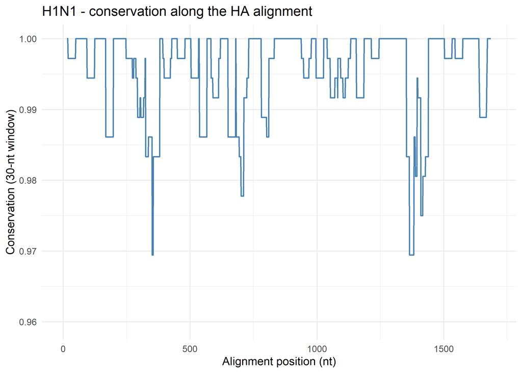

Figure 5. H1N1: conservation (30-nt window) along the HA alignment.

```r
plot_conservation(h1s, st)
```

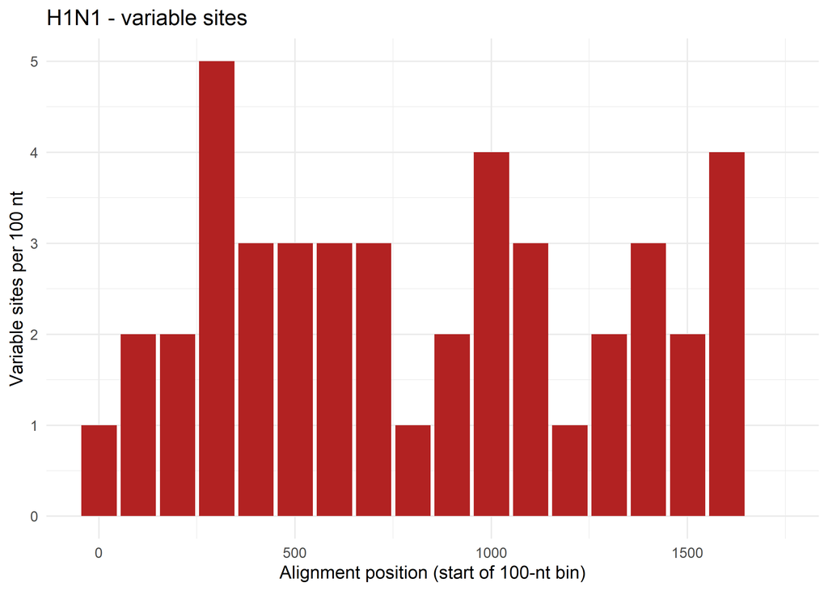

Figure 6. H1N1: number of variable sites in each 100-nt bin.

```r
plot_variable_bins(h1s, st)
```

```r
h1_blocks
```

| start | end | length |
| --- | --- | --- |
| 1 | 33 | 33 |
| 35 | 108 | 74 |
| 110 | 182 | 73 |
| 184 | 262 | 79 |
| 367 | 407 | 41 |
| 414 | 464 | 51 |
| 466 | 518 | 53 |
| 520 | 551 | 32 |
| 553 | 597 | 45 |
| 606 | 664 | 59 |

[output cut: 12 more lines]

## 6.3 Pairwise identity

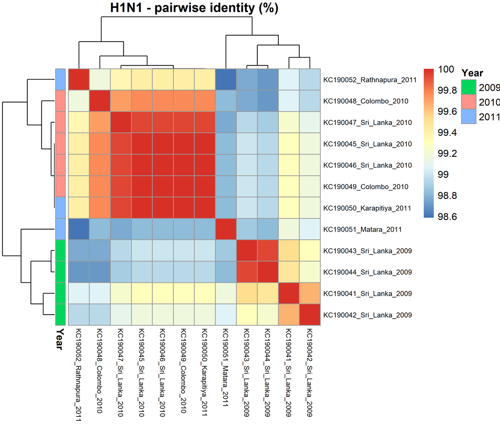

Figure 7. H1N1: pairwise nucleotide identity (%) between sequences.

```r
h1_pid <- plot_identity(h1$dnabin, st)
```

## 6.4 Phylogenetic tree

```r
h1t <- make_tree(h1$dnabin)
```

```
## Running bootstraps:       100 / 100
## Calculating bootstrap values... done.
```

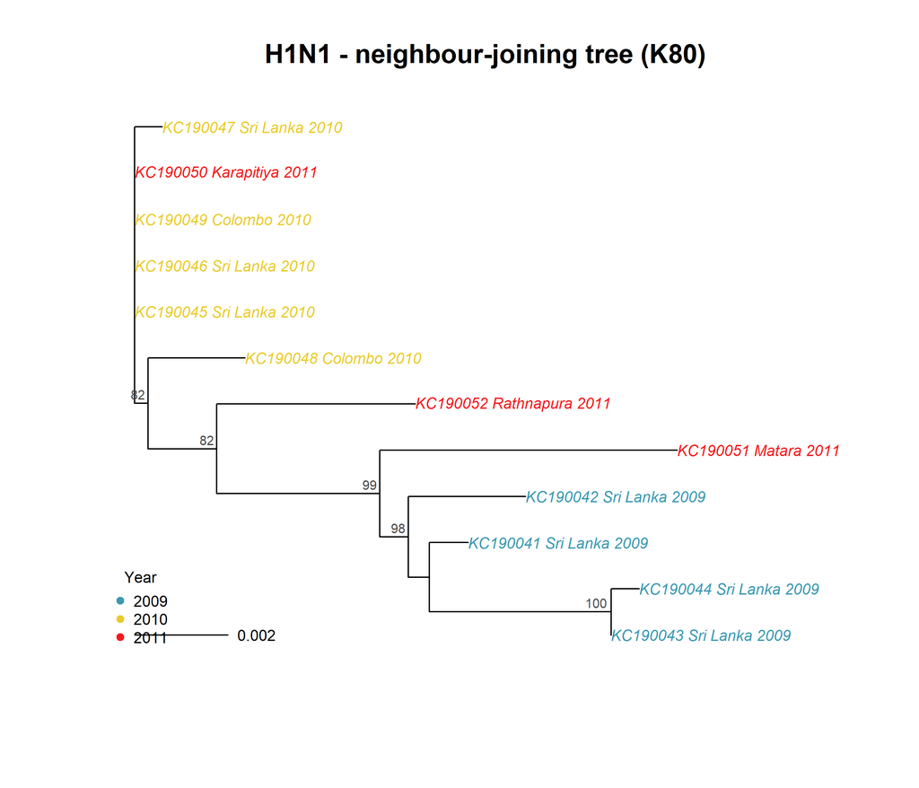

Figure 8. H1N1: neighbour-joining tree (Kimura 2-parameter distance), bootstrap support (%; only values >= 70 shown) and tip colour = year of collection.

```r
plot_tree(h1t, st)
```

```r
write.tree(h1t$tr, "../results/H1N1_tree.nwk")
```

# 7. Where do the changes happen? Codon positions and amino acids

All sequences are complete coding sequences (start with ATG, 1,701 nt, no gaps in the alignment), so alignment position 1 is the first base of codon 1. Mutations at the 3rd codon position are often *synonymous* (no amino-acid change).

```r
if (length(unique(width(fa))) != 1 || any(h1s$gap_frac > 0)) {
  warning("Sequences differ in length or the alignment has gaps: ",
          "alignment positions may not equal codon positions.")
}

codon_tab <- h1s |>
  mutate(codon_position = ((pos - 1) %% 3) + 1) |>
  group_by(codon_position) |>
  summarise(sites = n(), variable_sites = sum(variable),
            pct_variable = round(100 * mean(variable), 1), .groups = "drop")
codon_tab
```

| codon_position | sites | variable_sites | pct_variable |
| --- | --- | --- | --- |
| 1 | 567 | 12 | 2.1 |
| 2 | 567 | 12 | 2.1 |
| 3 | 567 | 20 | 3.5 |

```r
write_csv(codon_tab, "../results/H1N1_variable_sites_by_codon_position.csv")
```

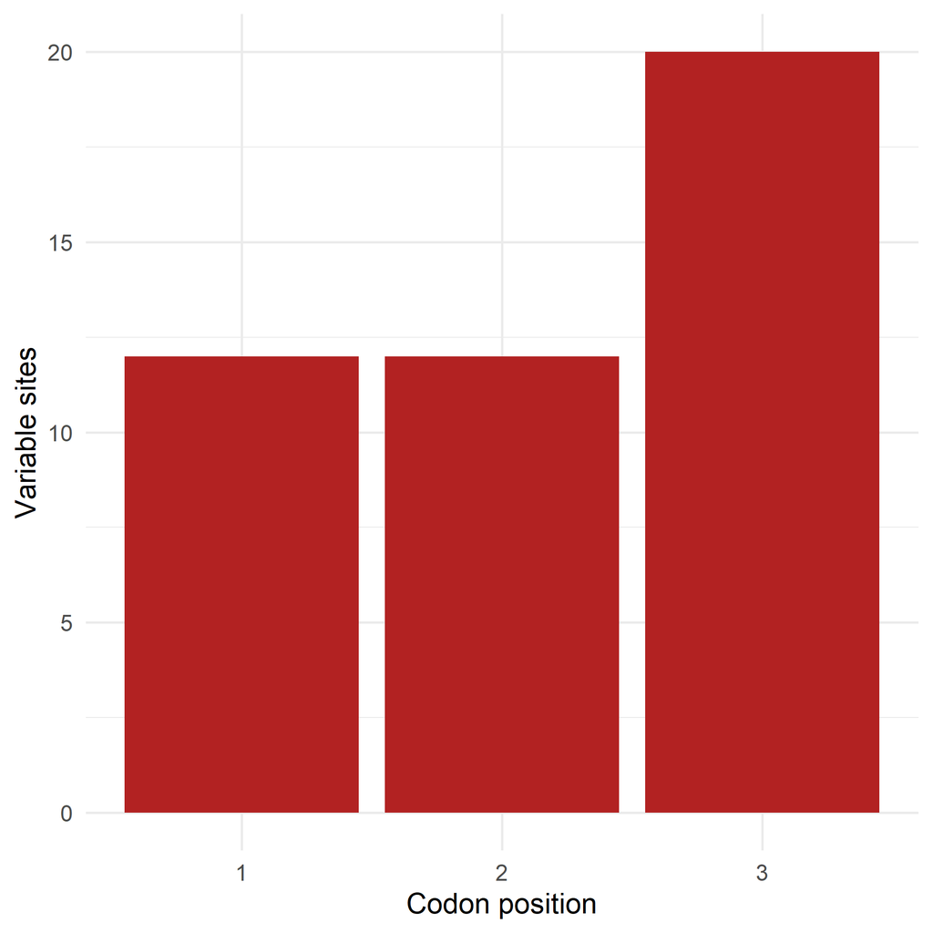

Figure 9. H1N1: number of variable nucleotide sites at each codon position.

```r
ggplot(codon_tab, aes(factor(codon_position), variable_sites)) +
  geom_col(fill = "firebrick") +
  labs(x = "Codon position", y = "Variable sites") +
  theme_minimal()
```

Translate the sequences and count variable **amino-acid** positions:

```r
aa   <- translate(fa, if.fuzzy.codon = "X")     # ambiguous codons become X
aa_m <- as.matrix(aa)

aa_var <- apply(aa_m, 2, function(x) {
  x <- x[!x %in% c("X", "*")]
  length(unique(x)) > 1
})

cat("Amino-acid positions:", ncol(aa_m), "\n")
```

```
## Amino-acid positions: 567
```

```r
cat("Variable amino-acid positions:", sum(aa_var), "\n")
```

```
## Variable amino-acid positions: 23
```

```r
cat("Positions (1 = first residue):", which(aa_var), "\n")
```

```
## Positions (1 = first residue): 12 88 101 103 114 138 155 200 202 222 233 237 239 266 273 338 366 370 373 391 468 552 553
```

Summary table:

```r
summarise_alignment(h1, h1s, "H1N1") |>
  mutate(variable_aa_positions = sum(aa_var)) |>
  write_csv("../results/alignment_summary.csv")

read_csv("../results/alignment_summary.csv", show_col_types = FALSE)
```

| subtype | sequences | alignment_length | variable_sites | variable_pct | fully_conserved | mean_identity_pct | min_identity_pct | variable_aa_positions |
| --- | --- | --- | --- | --- | --- | --- | --- | --- |
| H1N1 | 12 | 1701 | 44 | 2.6 | 1657 | 99.27 | 98.59 | 23 |

# 8. Notes for the Discussion section

Look at your own results and answer:

1. Does GC content differ between 2009, 2010 and 2011 (Kruskal-Wallis p-value)? Remember `n` is small.
2. How many nucleotide sites vary, and how are they spread along the gene? Sequences this similar (about 99% identity) show few variable sites, so describe the pattern carefully. Positions are alignment positions: the sequences are complete coding sequences, so position 1 = codon 1.
3. Which codon position carries most of the variable sites, and what does it suggest (synonymous vs amino-acid changes)? How many amino-acid positions vary?
4. How long are the conserved blocks, and why might conserved regions matter (receptor binding, membrane fusion, structure, primer design)?
5. Do the sequences cluster by year, by location, or neither? Are any nodes supported at 70% or more? With such similar sequences, short branches and low bootstrap values are expected.
6. Limitations: only 12 sequences, one subtype, one country and a 3-year window; sampling bias; a distance-based tree (neighbour-joining) rather than maximum likelihood; no selection (dN/dS) analysis.
7. Future work: add H3N2 or global H1N1 sequences, maximum-likelihood trees (`phangorn`, IQ-TREE), dN/dS, mapping variable sites onto the HA protein structure.